# Portafolio de trabajos Estadistica A0501

### **Resolución de Ejercicios propuestos:**

**REGRESIÓN LINEAL SIMPLE**

Resuelva solo los ejercicios impares, y en cada caso, realice las pruebas individuales, el contraste global F, calcule los coeficientes de determinación y ajustado. Construya los intervalos de predicción en los casos que aplique.

**11.3** Se realizó un estudio sobre la cantidad de azúcar convertida, en cierto proceso, a distintas temperaturas. Los datos se codiﬁcaron y registraron como sigue:

[output not shown]

1. Estime la recta de regresión lineal.
2. Calcule la cantidad media de azúcar convertida que se produce cuando la temperatura registrada es 1.75.
3. Graﬁque los residuos contra la temperatura. Comente el resultado.

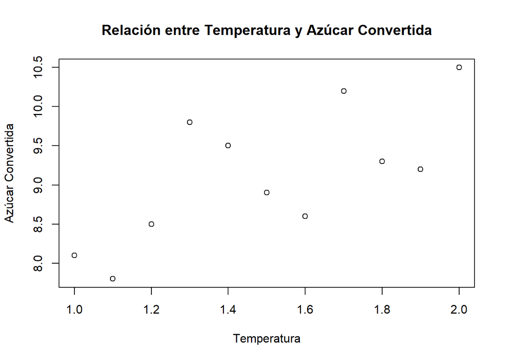

```r
x <- c(1.0, 1.1, 1.2, 1.3, 1.4, 1.5, 1.6, 1.7, 1.8, 1.9, 2.0) # Temperatura
y <- c(8.1, 7.8, 8.5, 9.8, 9.5, 8.9, 8.6, 10.2, 9.3, 9.2, 10.5) # Azúcar convertida

# Grafico de dispersion
plot(x, y, main="Relación entre Temperatura y Azúcar Convertida", xlab="Temperatura", ylab="Azúcar Convertida")
```

```r
# Estimar el modelo de regresión lineal
modelo <- lm(y ~ x)

# Resumen del modelo para obtener los coeficientes
summary(modelo)
```

```
##
## Call:
## lm(formula = y ~ x)
##
## Residuals:
##     Min      1Q  Median      3Q     Max
## -0.7082 -0.4868 -0.1227  0.5109  1.0346
##
## Coefficients:
##             Estimate Std. Error t value Pr(>|t|)
## (Intercept)   6.4136     0.9246   6.936 6.79e-05 ***
## x             1.8091     0.6032   2.999    0.015 *
## ---
## Signif. codes:  0 '***' 0.001 '**' 0.01 '*' 0.05 '.' 0.1 ' ' 1
##
## Residual standard error: 0.6326 on 9 degrees of freedom
## Multiple R-squared:  0.4999, Adjusted R-squared:  0.4443
## F-statistic: 8.996 on 1 and 9 DF,  p-value: 0.01497
```

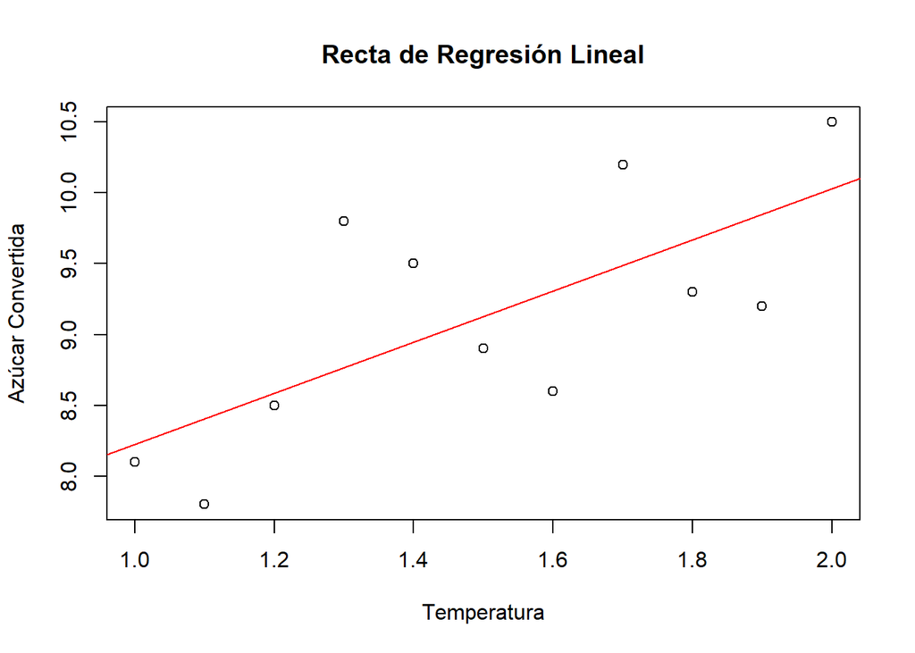

```r
# Proyecciones de Y (valores ajustados)
Yproy <- predict(modelo)

# Graficar la recta de regresión
plot(x, y, main="Recta de Regresión Lineal", xlab="Temperatura", ylab="Azúcar Convertida")
abline(modelo, col="red")
```

```r
# Residuos de la regresión
resid <- residuals(modelo)

# Graficar los residuos contra la temperatura
plot(x, resid, main="Residuos vs Temperatura", xlab="Temperatura", ylab="Residuos")
abline(h = 0, col = "red")

# Predicción para temperatura 1.75
x0 <- 1.75
y_pred <- predict(modelo, newdata = data.frame(x = x0))
y_pred
```

[output not shown]

```
##        1
## 9.579545
```

```r
# Intervalo de confianza para la media condicionada y predicción puntual para x = 1.75
predict(modelo, newdata = data.frame(x = x0), interval = "confidence", level = 0.95)
```

```
##        fit      lwr      upr
## 1 9.579545 9.029514 10.12958
```

```r
predict(modelo, newdata = data.frame(x = x0), interval = "prediction", level = 0.95)
```

```
##        fit      lwr      upr
## 1 9.579545 8.046425 11.11267
```

```r
library(lmtest)
```

[figure not shown]

```r
dwtest(modelo) # Test de Durbin-Watson para independencia
```

```
##
##  Durbin-Watson test
##
## data:  modelo
## DW = 2.0376, p-value = 0.3731
## alternative hypothesis: true autocorrelation is greater than 0
```

```r
# Verificación de homocedasticidad
library(lawstat)
levene.test(y, as.factor(x)) # Levene test para homocedasticidad
```

```
##
##  Modified robust Brown-Forsythe Levene-type test based on the absolute
##  deviations from the median
##
## data:  y
## Test Statistic = NaN, p-value = NA
```

```r
# Verificación de normalidad de los residuos
shapiro.test(resid)
```

```
##
##  Shapiro-Wilk normality test
##
## data:  resid
## W = 0.91869, p-value = 0.3079
```

**11.5**

Se registraron las cantidades de un compuesto químico, y, que se disolvía en 100 gramos de agua a distintas temperaturas:

| x(°C) | y(gramos) |
| --- | --- |
| 0 | 8, 6, 8 |
| 15 | 12, 10, 14 |
| 30 | 25, 21, 24 |
| 45 | 31, 33, 28 |
| 60 | 44, 39, 42 |
| 75 | 48, 51, 44 |

1. Encuentre la recta de regresión.
2. Grafique la recta en un diagrama de dispersión.
3. Estime la cantidad de producto químico que se disolverá en 100 gramos de agua a 50 °C

```r
# Datos de entrada
x <- c(0, 15, 30, 45, 60, 75)  # Temperaturas

# Datos de y (3 hileras para cada temperatura)
y_0 <- c(8, 6, 8)
y_15 <- c(12, 10, 14)
y_30 <- c(25, 21, 24)
y_45 <- c(31, 33, 28)
y_60 <- c(44, 39, 42)
y_75 <- c(48, 51, 44)

# Calcular el promedio de y para cada temperatura
y <- c(mean(y_0), mean(y_15), mean(y_30), mean(y_45), mean(y_60), mean(y_75))

# Mostrar los valores de x y los promedios de y
x
```

```
## [1]  0 15 30 45 60 75
```

```r
y
```

```
## [1]  7.333333 12.000000 23.333333 30.666667 41.666667 47.666667
```

```r
# Estimar el modelo de regresión lineal
modelo <- lm(y ~ x)

# Resumen del modelo para obtener los coeficientes
summary(modelo)
```

```
##
## Call:
## lm(formula = y ~ x)
##
## Residuals:
##       1       2       3       4       5       6
##  1.5079 -2.3397  0.4794 -0.7016  1.7841 -0.7302
##
## Coefficients:
##             Estimate Std. Error t value Pr(>|t|)
## (Intercept)  5.82540    1.26326   4.611  0.00995 **
## x            0.56762    0.02782  20.406 3.41e-05 ***
## ---
## Signif. codes:  0 '***' 0.001 '**' 0.01 '*' 0.05 '.' 0.1 ' ' 1
##
## Residual standard error: 1.745 on 4 degrees of freedom
## Multiple R-squared:  0.9905, Adjusted R-squared:  0.9881
## F-statistic: 416.4 on 1 and 4 DF,  p-value: 3.405e-05
```

```r
# Mostrar la ecuación de la recta de regresión
coef(modelo)
```

```
## (Intercept)           x
##    5.825397    0.567619
```

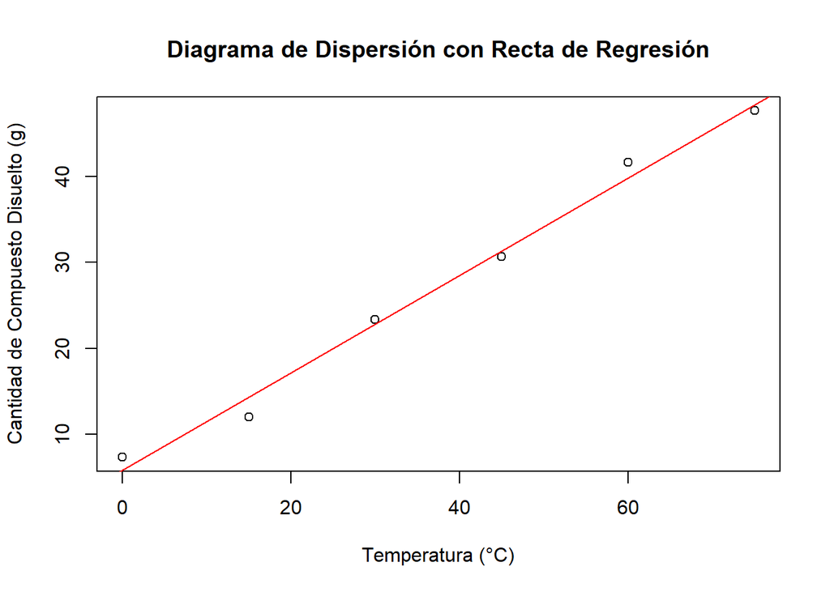

```r
# Graficar el diagrama de dispersión y la recta de regresión
plot(x, y, main="Diagrama de Dispersión con Recta de Regresión",
     xlab="Temperatura (°C)", ylab="Cantidad de Compuesto Disuelto (g)")
abline(modelo, col="red")
```

```r
# Predicción para x = 50°C
x_nueva <- data.frame(x = 50)
y_pred <- predict(modelo, newdata = x_nueva)
y_pred
```

```
##        1
## 34.20635
```

**11.7**

Un comerciante al detalle realizó un estudio para determinar la relación que hay entre los gastos de la publicidad semanal y las ventas. Registró los datos siguientes: costos de publicidad

| Costo de publicidad ($s$) | Ventas($s$) |
| --- | --- |
| 40 | 385 |
| 20 | 400 |
| 25 | 395 |
| 20 | 365 |
| 30 | 475 |
| 50 | 440 |
| 40 | 490 |
| 20 | 420 |
| 50 | 560 |
| 40 | 525 |
| 25 | 480 |
| 50 | 510 |

1. Elabore un diagrama de dispersión.
2. Encuentre la ecuación de regresión para pronosticar las ventas semanales, a partir de los gastos en publicidad.
3. Estime las ventas semanales cuando los costos de la publicidad sean de $35.
4. Graﬁque los residuos contra los costos de publicidad. Haga comentarios.

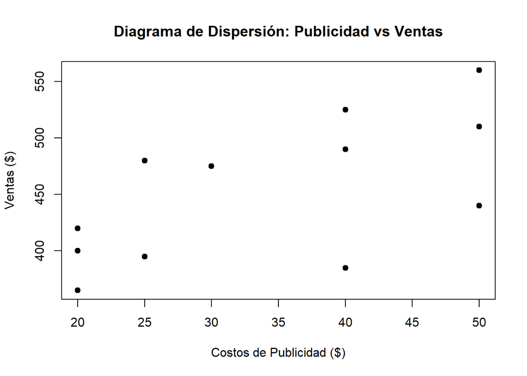

```r
x <- c(40, 20, 25, 20, 30, 50, 40, 20, 50, 40, 25, 50)  # Costos de publicidad
y <- c(385, 400, 395, 365, 475, 440, 490, 420, 560, 525, 480, 510)  # Ventas

# Graficar el diagrama de dispersión
plot(x, y, main="Diagrama de Dispersión: Publicidad vs Ventas",
     xlab="Costos de Publicidad ($)", ylab="Ventas ($)", pch=19)
```

```r
# Estimar el modelo de regresión lineal
modelo <- lm(y ~ x)

# Resumen del modelo para obtener los coeficientes
summary(modelo)
```

```
##
## Call:
## lm(formula = y ~ x)
##
## Residuals:
##     Min      1Q  Median      3Q     Max
## -87.538 -32.700   8.566  39.118  55.774
##
## Coefficients:
##             Estimate Std. Error t value Pr(>|t|)
## (Intercept)  343.706     44.766   7.678 1.68e-05 ***
## x              3.221      1.240   2.598   0.0266 *
## ---
## Signif. codes:  0 '***' 0.001 '**' 0.01 '*' 0.05 '.' 0.1 ' ' 1
##
## Residual standard error: 50.23 on 10 degrees of freedom
## Multiple R-squared:  0.403,  Adjusted R-squared:  0.3433
## F-statistic: 6.751 on 1 and 10 DF,  p-value: 0.02657
```

```r
# Mostrar la ecuación de la recta de regresión
coef(modelo)
```

```
## (Intercept)           x
##  343.705584    3.220812
```

```r
# Predicción para x = 35 (costos de publicidad)
x_nueva <- data.frame(x = 35)
y_pred <- predict(modelo, newdata = x_nueva)
y_pred
```

```
##       1
## 456.434
```

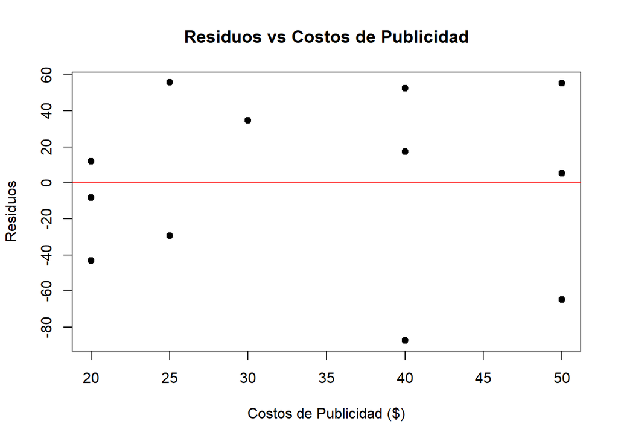

```r
# Calcular los residuos
residuos <- residuals(modelo)

# Graficar los residuos contra los costos de publicidad
plot(x, residuos, main="Residuos vs Costos de Publicidad",
     xlab="Costos de Publicidad ($)", ylab="Residuos", pch=19)
abline(h = 0, col="red")
```

**11.9** Un estudio sobre la cantidad de lluvia y la de contaminación removida del aire produjo los siguientes datos:

| Cantidad de lluvia diaria ($0.01cm$) | Ventas($\mu g/m^3$) |
| --- | --- |
| 4.3 | 126 |
| 4.5 | 121 |
| 5.9 | 116 |
| 5.6 | 118 |
| 6.1 | 114 |
| 5.2 | 118 |
| 3.8 | 132 |
| 2.1 | 141 |
| 7.5 | 108 |

1. Obtenga la ecuación de la recta de regresión para pronosticar las partículas removidas, a partir de la cantidad de lluvia diaria.
2. Estime la cantidad de partículas removidas cuando la lluvia diaria es x = 4.8 unidades.

```r
x <- c(4.3, 4.5, 5.9, 5.6, 6.1, 5.2, 3.8, 2.1, 7.5)  # Cantidad de lluvia diaria en 0.01 cm
y <- c(126, 121, 116, 118, 114, 118, 132, 141, 108)  # Partículas removidas

n <- length(x)  # Total de pares ordenados (X, Y)

# Vector de medias
vecmed <- c(mean(x), mean(y))
vecmed
```

```
## [1]   5.0000 121.5556
```

```r
# Covarianza muestral
Sxy <- sum((x - mean(x)) * (y - mean(y))) / n
Sxy
```

```
## [1] -13.53333
```

```r
# Covarianza cuadrada de x
S2x <- sum((x - mean(x))^2) / n
S2x
```

```
## [1] 2.14
```

```r
# ESTIMACION DE LOS BETAS
# Para Beta 1
Beta1 <- Sxy / S2x
Beta1
```

```
## [1] -6.323988
```

```r
# Para Beta 0
Beta0 <- mean(y) - Beta1 * mean(x)
Beta0
```

```
## [1] 153.1755
```

```r
# Mostrar la ecuación de la recta de regresión
cat("La ecuación de la recta de regresión es: y =", Beta0, "+", Beta1, "* x\n")
```

```
## La ecuación de la recta de regresión es: y = 153.1755 + -6.323988 * x
```

```r
# PREDICCION PARA x = 4.8
x0 <- 4.8
y0 <- Beta0 + Beta1 * x0
cat("La cantidad estimada de partículas removidas cuando x = 4.8 es:", y0, "\n")
```

```
## La cantidad estimada de partículas removidas cuando x = 4.8 es: 122.8204
```

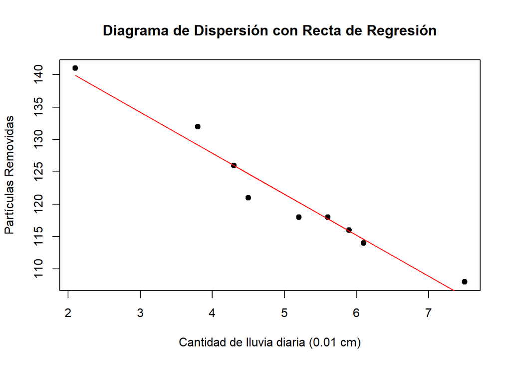

```r
# Proyecciones de Y (valores estimados)
Yproy <- Beta0 + Beta1 * x

# Grafico de la recta de regresión
plot(x, y, main="Diagrama de Dispersión con Recta de Regresión",
     xlab="Cantidad de lluvia diaria (0.01 cm)", ylab="Partículas Removidas", pch=19)
lines(x, Yproy, col="red")
```

**11.11**

El empuje de un motor (y) es función de la temperatura de escape (x) en ◦ F, cuando otras variables de importancia se mantienen constantes. Considere los siguientes datos:

[output not shown]

1. Graﬁque los datos.
2. Ajuste una recta de regresión simple a los datos y grafíquela a través de ellos.

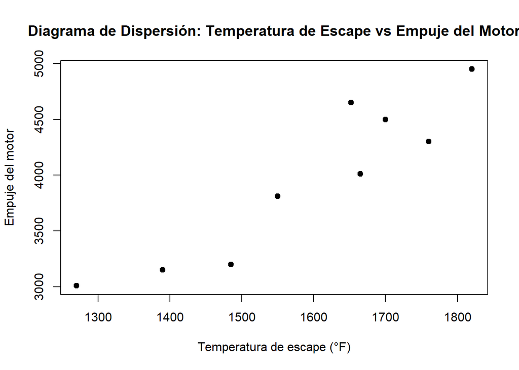

```r
x <- c(1760, 1652, 1485, 1390, 1820, 1665, 1550, 1700, 1270)  # Temperatura de escape (°F)
y <- c(4300, 4650, 3200, 3150, 4950, 4010, 3810, 4500, 3008)  # Empuje del motor

# Grafico de dispersión
plot(x, y, main="Diagrama de Dispersión: Temperatura de Escape vs Empuje del Motor",
     xlab="Temperatura de escape (°F)", ylab="Empuje del motor", pch=19)
```

```r
# Ajustar el modelo de regresión lineal
modelo <- lm(y ~ x)

# Mostrar la ecuación de la recta de regresión
coef(modelo)
```

```
##  (Intercept)            x
## -1847.633004     3.652862
```

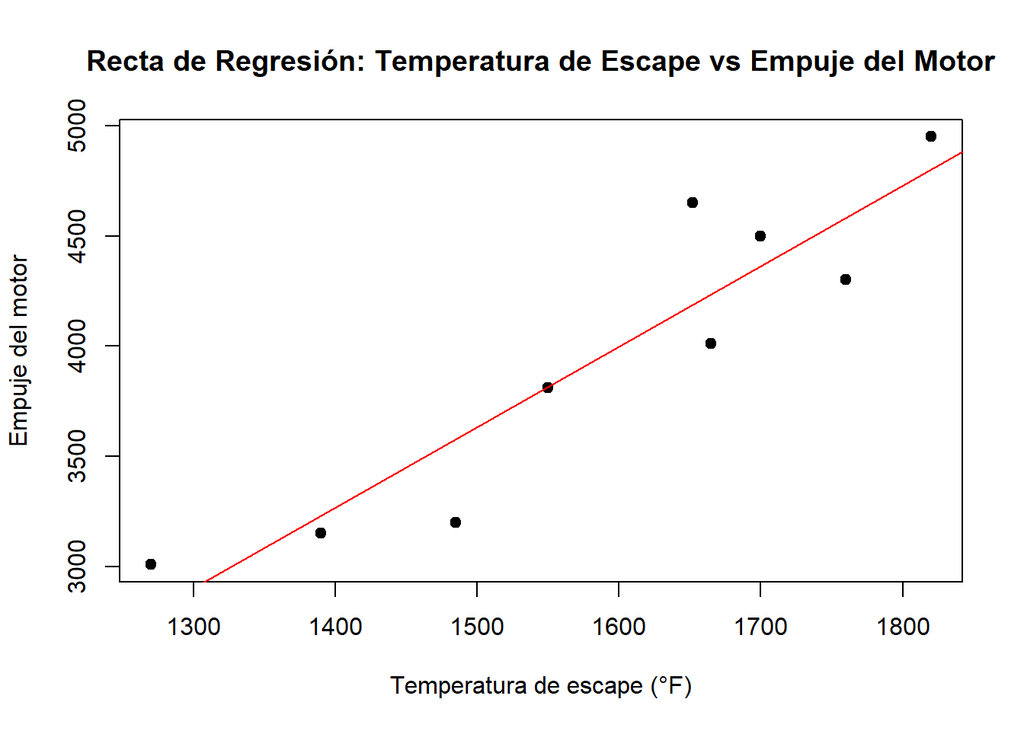

```r
# Graficar la recta de regresión sobre el diagrama de dispersión
plot(x, y, main="Recta de Regresión: Temperatura de Escape vs Empuje del Motor",
     xlab="Temperatura de escape (°F)", ylab="Empuje del motor", pch=19)
abline(modelo, col="red")
```

**REGRESIÓN LINEAL MULTIPLE**

*Resuelva solo los ejercicios impares, y en cada caso, realice las pruebas individuales, el contraste global F, calcule los coeficientes de determinación y ajustado. Construya los intervalos de predicción en los casos que aplique.*

**12.3**

Se efectuó un conjunto de ensayos experimentales para determinar una forma de predecir el tiempo de cocción y a diferentes niveles del ancho de horno x1 y temperaturas de la chimenea x2. Los siguientes son los datos registrados:

```r
y <- c(6.40, 15.05, 18.75, 30.25, 44.85, 48.94, 51.55, 61.50, 100.44, 111.12)  # Tiempo de cocción
x1 <- c(1.32, 2.69, 3.56, 4.41, 5.35, 6.20, 7.12, 8.87, 9.80, 10.65)  # Ancho del horno
x2 <- c(1.15, 3.40, 4.10, 8.75, 14.82, 15.15, 15.32, 18.18, 35.19, 40.40)  # Temperatura de la chimenea
```

Estime la ecuación de regresión lineal múltiple

```r
# Crear un data frame con los datos
datos <- data.frame(y, x1, x2)

# Ajustar el modelo de regresión lineal múltiple
modelo <- lm(y ~ x1 + x2, data = datos)

# Mostrar un resumen del modelo para obtener los coeficientes y estadísticas
summary(modelo)
```

```
##
## Call:
## lm(formula = y ~ x1 + x2, data = datos)
##
## Residuals:
##     Min      1Q  Median      3Q     Max
## -0.9829 -0.3689 -0.0199  0.2398  1.2887
##
## Coefficients:
##             Estimate Std. Error t value Pr(>|t|)
## (Intercept)  0.56345    0.65987   0.854    0.421
## x1           2.73690    0.21974  12.455 4.95e-06 ***
## x2           2.03939    0.05228  39.007 1.89e-09 ***
## ---
## Signif. codes:  0 '***' 0.001 '**' 0.01 '*' 0.05 '.' 0.1 ' ' 1
##
## Residual standard error: 0.7144 on 7 degrees of freedom
## Multiple R-squared:  0.9997, Adjusted R-squared:  0.9996
## F-statistic: 1.069e+04 on 2 and 7 DF,  p-value: 6.334e-13
```

```r
R2 <- summary(modelo)$r.squared
R2_adj <- summary(modelo)$adj.r.squared

cat("Coeficiente de determinación (R^2):", R2, "\n")
```

```
## Coeficiente de determinación (R^2): 0.9996728
```

```r
cat("Coeficiente de determinación ajustado (R^2 ajustado):", R2_adj, "\n")
```

```
## Coeficiente de determinación ajustado (R^2 ajustado): 0.9995794
```

```r
# Valores nuevos para x1 y x2
nuevos_datos <- data.frame(x1 = c(5.0), x2 = c(10.0))

# Calcular el intervalo de predicción
predicciones <- predict(modelo, newdata = nuevos_datos, interval = "prediction", level = 0.95)
print(predicciones)
```

```
##        fit      lwr     upr
## 1 34.64189 32.84849 36.4353
```

**12.5**

1. Ajuste una ecuación de regresión múltiple de la forma a los datos del ejemplo 11.8.
2. Estime el producto de la reacción química para una temperatura de 225 ◦C.

```r
y = c(13, 18, 16, 15, 20, 86, 90, 88, 88, 92)  # Lectura de la escala
x1 = c(10, 10, 10, 10, 10, 50, 50, 50, 50, 50)  # Presión
x2 = c(1, 1, 1, 1, 1, 1, 1, 1, 1, 1)  # Para mantener la estructura del modelo múltiple, aunque no se necesite realmente aquí

n = length(y)  # Número de observaciones
p = 2  # Número de coeficientes beta a estimar (incluyendo el intercepto)

# Construir las matrices
Y = matrix(y, nrow = n)  # Vector Y
X = matrix(c(rep(1,n), x1), ncol = p)  # Matriz de diseño

# Construir el sistema de ecuaciones normales A*beta = b
A = t(X) %*% X  # Multiplicación matricial
b = t(X) %*% Y

# Estimar el vector Beta
Ainv = solve(A)  # Matriz inversa de A
Beta = Ainv %*% b  # Estimación por MCO del vector Beta
Beta
```

```
##       [,1]
## [1,] -1.70
## [2,]  1.81
```

```r
# Proyecciones de Y
Yproy = X %*% Beta
Yproy
```

```
##       [,1]
##  [1,] 16.4
##  [2,] 16.4
##  [3,] 16.4
##  [4,] 16.4
##  [5,] 16.4
##  [6,] 88.8
##  [7,] 88.8
##  [8,] 88.8
##  [9,] 88.8
## [10,] 88.8
```

```r
# Residuos
resid = Y - Yproy
resid
```

```
##       [,1]
##  [1,] -3.4
##  [2,]  1.6
##  [3,] -0.4
##  [4,] -1.4
##  [5,]  3.6
##  [6,] -2.8
##  [7,]  1.2
##  [8,] -0.8
##  [9,] -0.8
## [10,]  3.2
```

```r
# sumatoria de residuos
sum(resid)  # Debería ser muy cercana a cero
```

```
## [1] -1.385558e-13
```

```r
# Suma cuadrada de residuos (SCR)
SCR = sum(resid^2)
SCR
```

```
## [1] 50
```

```r
# Estimación de la varianza del error
sigma2 = SCR / (n - p)
sigma = sqrt(sigma2)
sigma
```

```
## [1] 2.5
```

```r
# Ajustar el modelo de regresión lineal múltiple usando la función lm
RLM1 = lm(y ~ x1)

# Predicción para una presión de 225
x0 = data.frame(x1 = 225)
prediccion = predict(RLM1, newdata = x0)
prediccion
```

```
##      1
## 405.55
```

```r
# También calcular los intervalos de predicción
predict(RLM1, newdata = x0, interval = "prediction", level = 0.95)
```

```
##      fit     lwr     upr
## 1 405.55 386.775 424.325
```

```r
# Prueba F global
SCT = sum((Y - mean(Y))^2)  # Suma de cuadrados total
SCReg = sum((Yproy - mean(Y))^2)  # Suma de cuadrados de la regresión
F.test = (SCReg /(p-1)) / (SCR / (n-p))
Pvalor.F = 1 - pf(F.test, (p-1), (n-p))

# Mostrar resultados
F.test
```

```
## [1] 2096.704
```

```r
Pvalor.F
```

```
## [1] 5.716305e-11
```

```r
# Coeficientes de determinación
R2 = 1 - SCR/SCT
R2adj = 1 - ((SCR/(n-p)) / (SCT/(n-1)))

cat("Coeficiente de determinación (R^2):", R2, "\n")
```

```
## Coeficiente de determinación (R^2): 0.996199
```

```r
cat("Coeficiente de determinación ajustado (R^2 ajustado):", R2adj, "\n")
```

```
## Coeficiente de determinación ajustado (R^2 ajustado): 0.9957239
```

**12.7**

Se efectuó un experimento con la ﬁnalidad de determinar si el ﬂujo sanguíneo cerebral de los seres humanos podía predecirse a partir de la tensión arterial del oxígeno (milímetros de mercurio). En el estudio se utilizaron 15 pacientes y se observaron los siguientes datos:

```r
y <- c(84.33, 87.80, 82.20, 78.21, 78.44, 80.01, 83.53, 79.46, 75.22, 76.58, 77.90, 78.80, 80.67, 86.60, 78.20)  # Flujo sanguíneo
x <- c(603.40, 582.50, 556.20, 594.60, 558.90, 575.20, 580.10, 451.20, 404.00, 484.00, 452.40, 448.40, 334.80, 320.30, 350.30)  # Tensión arterial del oxígeno
```

Estime la ecuación de regresión cuadrática

```r
y <- c(84.33, 87.80, 82.20, 78.21, 78.44, 80.01, 83.53, 79.46, 75.22, 76.58, 77.90, 78.80, 80.67, 86.60, 78.20)  # Flujo sanguíneo
x <- c(603.40, 582.50, 556.20, 594.60, 558.90, 575.20, 580.10, 451.20, 404.00, 484.00, 452.40, 448.40, 334.80, 320.30, 350.30)  # Tensión arterial del oxígeno

n <- length(y)  # Número de observaciones
p <- 3  # Número de coeficientes beta a estimar (incluye el término cuadrático y el intercepto)

# Construir las matrices
x2 <- x^2  # Crear el término cuadrático
Y <- matrix(y, nrow = n)  # Vector Y
X <- matrix(c(rep(1, n), x, x2), ncol = p)  # Matriz de diseño con término cuadrático

# Mostrar las matrices
Y
```

```
##        [,1]
##  [1,] 84.33
##  [2,] 87.80
##  [3,] 82.20
##  [4,] 78.21
##  [5,] 78.44
##  [6,] 80.01
##  [7,] 83.53
##  [8,] 79.46
##  [9,] 75.22
## [10,] 76.58
## [11,] 77.90
## [12,] 78.80
## [13,] 80.67
## [14,] 86.60
## [15,] 78.20
```

```r
X
```

```
##       [,1]  [,2]     [,3]
##  [1,]    1 603.4 364091.6
##  [2,]    1 582.5 339306.2
##  [3,]    1 556.2 309358.4
##  [4,]    1 594.6 353549.2
##  [5,]    1 558.9 312369.2
##  [6,]    1 575.2 330855.0
##  [7,]    1 580.1 336516.0
##  [8,]    1 451.2 203581.4
##  [9,]    1 404.0 163216.0
## [10,]    1 484.0 234256.0
## [11,]    1 452.4 204665.8
## [12,]    1 448.4 201062.6
## [13,]    1 334.8 112091.0
## [14,]    1 320.3 102592.1
## [15,]    1 350.3 122710.1
```

```r
# Construir el sistema de ecuaciones normales A*beta = b
A = t(X) %*% X  # Multiplicación matricial
b = t(X) %*% Y

# Estimar el vector Beta
Ainv = solve(A)  # Matriz inversa de A
Beta = Ainv %*% b  # Estimación por MCO del vector Beta
Beta  # Los coeficientes de la regresión cuadrática
```

```
##               [,1]
## [1,]  1.416118e+02
## [2,] -2.819271e-01
## [3,]  3.091408e-04
```

```r
# Proyecciones de Y
Yproy = X %*% Beta
Yproy
```

```
##           [,1]
##  [1,] 84.05254
##  [2,] 82.28267
##  [3,] 80.43926
##  [4,] 83.27442
##  [5,] 80.60881
##  [6,] 81.72812
##  [7,] 82.09672
##  [8,] 77.34162
##  [9,] 78.16997
## [10,] 77.57717
## [11,] 77.33851
## [12,] 77.35232
## [13,] 81.87451
## [14,] 83.02594
## [15,] 80.78742
```

```r
# Residuos
resid = Y - Yproy
resid
```

```
##             [,1]
##  [1,]  0.2774556
##  [2,]  5.5173307
##  [3,]  1.7607390
##  [4,] -5.0644165
##  [5,] -2.1688098
##  [6,] -1.7181230
##  [7,]  1.4332828
##  [8,]  2.1183841
##  [9,] -2.9499689
## [10,] -0.9971663
## [11,]  0.5614890
## [12,]  1.4476769
## [13,] -1.2045108
## [14,]  3.5740598
## [15,] -2.5874228
```

```r
# Suma de residuos
sum(resid)  # Debería ser muy cercana a cero
```

```
## [1] -5.688605e-10
```

```r
# Suma cuadrada de residuos (SCR)
SCR = sum(resid^2)
SCR
```

```
## [1] 106.4912
```

```r
# Estimación de la varianza del error
sigma2 = SCR / (n - p)
sigma = sqrt(sigma2)
sigma
```

```
## [1] 2.97897
```

```r
# Prueba F global
SCT = sum((Y - mean(Y))^2)  # Suma de cuadrados total
SCReg = sum((Yproy - mean(Y))^2)  # Suma de cuadrados de la regresión
F.test = (SCReg /(p-1)) / (SCR / (n-p))
Pvalor.F = 1 - pf(F.test, (p-1), (n-p))

# Mostrar resultados
F.test
```

```
## [1] 4.493794
```

```r
Pvalor.F
```

```
## [1] 0.03493915
```

```r
# Coeficientes de determinación
R2 = 1 - SCR/SCT
R2adj = 1 - ((SCR/(n-p)) / (SCT/(n-1)))

cat("Coeficiente de determinación (R^2):", R2, "\n")
```

```
## Coeficiente de determinación (R^2): 0.4282335
```

```r
cat("Coeficiente de determinación ajustado (R^2 ajustado):", R2adj, "\n")
```

```
## Coeficiente de determinación ajustado (R^2 ajustado): 0.3329391
```

```r
# Supongamos una nueva tensión arterial del oxígeno para predicción
x_nuevo <- 400  # Ejemplo de valor de x
x2_nuevo <- x_nuevo^2  # Termino cuadrático

# Crear vector de entrada
x0 <- c(1, x_nuevo, x2_nuevo)
Y0 <- x0 %*% Beta

# Intervalo de predicción para la media condicionada
LIC.Y0 = Y0 - qt(0.975, n-p) * sigma * sqrt(t(x0) %*% Ainv %*% x0)
LSC.Y0 = Y0 + qt(0.975, n-p) * sigma * sqrt(t(x0) %*% Ainv %*% x0)

cat("Intervalo de predicción para la media condicionada: [", LIC.Y0, ",", LSC.Y0, "]\n")
```

```
## Intervalo de predicción para la media condicionada: [ 75.74781 , 80.85915 ]
```

```r
# Intervalo de predicción puntual
LIC.P = Y0 - qt(0.975, n-p) * sigma * sqrt(1 + t(x0) %*% Ainv %*% x0)
LSC.P = Y0 + qt(0.975, n-p) * sigma * sqrt(1 + t(x0) %*% Ainv %*% x0)

cat("Intervalo de predicción puntual: [", LIC.P, ",", LSC.P, "]\n")
```

```
## Intervalo de predicción puntual: [ 71.32784 , 85.27912 ]
```

**12.9**

Se cree que la energía eléctrica consumida cada mes por una planta química está relacionada con la temperatura ambiental promedio x1, el número de días del mes x2, la pureza promedio del producto x3 y las toneladas fabricadas del producto x4. Se dispone de datos históricos

1. Ajuste un modelo de regresión lineal múltiple usando el conjunto de los datos anteriores.
2. Prediga el consumo de energía para un mes en que x1 = 75 ◦F, x2 = 24 días, x3 = 90% y x4 = 98 toneladas.

```r
y <- c(240,236,290,274,301,316,300,296,267,276,288,261)  # Energía consumida
x1 <- c(25,31,45,60,65,72,80,84,75,60,50,38)  # Temperatura promedio
x2 <- c(24,21,24,25,25,26,25,25,24,25,25,23)  # Número de días del mes
x3 <- c(91,90,88,87,91,94,87,86,88,91,90,89)  # Pureza promedio del producto
x4 <- c(100,95,110,88,94,99,97,96,110,105,100,98)  # Toneladas fabricadas

# Crear el dataframe con los datos
datos <- data.frame(y, x1, x2, x3, x4)

# Ajustar el modelo de regresión lineal múltiple
modelo <- lm(y ~ x1 + x2 + x3 + x4, data = datos)

# Resumen del modelo para obtener los coeficientes y estadísticas
summary(modelo)
```

```
##
## Call:
## lm(formula = y ~ x1 + x2 + x3 + x4, data = datos)
##
## Residuals:
##     Min      1Q  Median      3Q     Max
## -18.758  -9.952   3.350   6.627  23.311
##
## Coefficients:
##               Estimate Std. Error t value Pr(>|t|)
## (Intercept) -102.71324  207.85885  -0.494    0.636
## x1             0.60537    0.36890   1.641    0.145
## x2             8.92364    5.30052   1.684    0.136
## x3             1.43746    2.39162   0.601    0.567
## x4             0.01361    0.73382   0.019    0.986
##
## Residual standard error: 15.58 on 7 degrees of freedom
## Multiple R-squared:  0.7447, Adjusted R-squared:  0.5989
## F-statistic: 5.106 on 4 and 7 DF,  p-value: 0.0303
```

```r
# Datos para la predicción
nuevos_datos <- data.frame(x1 = 75, x2 = 24, x3 = 90, x4 = 98)

# Predicción del consumo de energía
prediccion <- predict(modelo, newdata = nuevos_datos)

# Mostrar el resultado de la predicción
cat("Predicción del consumo de energía:", prediccion, "unidades\n")
```

```
## Predicción del consumo de energía: 287.5618 unidades
```

```r
# También calcular los intervalos de predicción
intervalo_prediccion <- predict(modelo, newdata = nuevos_datos, interval = "prediction", level = 0.95)
print(intervalo_prediccion)
```

```
##        fit      lwr      upr
## 1 287.5618 243.7175 331.4062
```

**12.11**

Estime los coefi cientes de regresión del modelo

```r
y <- c(11.2,14.5,17.2,17.8,19.3,24.5,21.2,16.9,14.8,20.0,13.2,22.5)  # Calificación de desempeño
x1 <- c(56.5,59.5,69.2,74.5,81.2,88.0,78.2,69.0,58.1,80.5,58.3,84.0)  # Calificación del examen 1
x2 <- c(71.0,72.5,76.0,79.5,84.0,86.2,80.5,72.0,68.0,85.0,71.0,87.2)  # Calificación del examen 2
x3 <- c(38.5,38.2,42.5,43.4,47.5,47.4,44.5,41.8,42.1,48.1,37.5,51.0)  # Calificación del examen 3
x4 <- c(43.0,44.8,49.0,56.3,60.2,62.0,58.1,48.1,46.0,60.3,47.1,65.2)  # Calificación del examen 4

# Crear el dataframe con los datos
datos <- data.frame(y, x1, x2, x3, x4)

# Ajustar el modelo de regresión lineal múltiple
modelo <- lm(y ~ x1 + x2 + x3 + x4, data = datos)

# Resumen del modelo para obtener los coeficientes y estadísticas
summary(modelo)
```

```
##
## Call:
## lm(formula = y ~ x1 + x2 + x3 + x4, data = datos)
##
## Residuals:
##     Min      1Q  Median      3Q     Max
## -1.6462 -0.8679  0.1327  0.7277  1.3610
##
## Coefficients:
##             Estimate Std. Error t value Pr(>|t|)
## (Intercept)  3.32046    9.36616   0.355   0.7334
## x1           0.42105    0.13265   3.174   0.0156 *
## x2          -0.29578    0.23179  -1.276   0.2426
## x3           0.01638    0.24810   0.066   0.9492
## x4           0.12465    0.24197   0.515   0.6223
## ---
## Signif. codes:  0 '***' 0.001 '**' 0.01 '*' 0.05 '.' 0.1 ' ' 1
##
## Residual standard error: 1.222 on 7 degrees of freedom
## Multiple R-squared:  0.939,  Adjusted R-squared:  0.9042
## F-statistic: 26.94 on 4 and 7 DF,  p-value: 0.0002402
```

**12.13** Se realizó un experimento para estudiar el tamaño de los calamares consumidos por tiburones y atunes. Las variables regresoras son características del pico o la boca del calamar. Las variables regresoras y la respuesta considerada para el estudio son las siguientes:

```r
x1 <- c(1.31,1.55,0.99,0.99,1.01,1.09,1.08,1.27,0.99,1.34,1.30,1.33,1.86,1.58,1.97,1.80,1.75,1.72,1.68,1.75,2.19,1.73)  # Longitud del morro
x2 <- c(1.07,1.49,0.84,0.83,0.90,0.93,0.90,1.08,0.85,1.13,1.10,1.10,1.47,1.34,1.59,1.56,1.58,1.43,1.57,1.59,1.86,1.67)  # Longitud de aleta
x3 <- c(0.44,0.53,0.34,0.34,0.36,0.42,0.40,0.44,0.36,0.45,0.45,0.48,0.60,0.52,0.67,0.66,0.63,0.64,0.72,0.68,0.75,0.64)  # Longitud del morro a la cola
x4 <- c(0.75,0.90,0.57,0.54,0.64,0.61,0.51,0.77,0.56,0.77,0.76,0.77,1.01,0.95,1.20,1.02,1.09,1.02,0.96,1.08,1.24,1.14)  # Longitud de la cola a la aleta
x5 <- c(0.35,0.47,0.32,0.27,0.30,0.31,0.31,0.34,0.29,0.37,0.38,0.38,0.65,0.50,0.59,0.59,0.59,0.63,0.68,0.62,0.72,0.55)  # Ancho
y <- c(1.95,2.90,0.72,0.81,1.09,1.22,1.02,1.93,0.64,2.08,1.98,1.90,8.56,4.49,8.49,6.17,7.54,6.36,7.63,7.78,10.15,6.88)  # Peso
```

Estime la ecuación de regresión lineal múltiple

```r
x1 <- c(1.31,1.55,0.99,0.99,1.01,1.09,1.08,1.27,0.99,1.34,1.30,1.33,1.86,1.58,1.97,1.80,1.75,1.72,1.68,1.75,2.19,1.73)  # Longitud del morro
x2 <- c(1.07,1.49,0.84,0.83,0.90,0.93,0.90,1.08,0.85,1.13,1.10,1.10,1.47,1.34,1.59,1.56,1.58,1.43,1.57,1.59,1.86,1.67)  # Longitud de aleta
x3 <- c(0.44,0.53,0.34,0.34,0.36,0.42,0.40,0.44,0.36,0.45,0.45,0.48,0.60,0.52,0.67,0.66,0.63,0.64,0.72,0.68,0.75,0.64)  # Longitud del morro a la cola
x4 <- c(0.75,0.90,0.57,0.54,0.64,0.61,0.51,0.77,0.56,0.77,0.76,0.77,1.01,0.95,1.20,1.02,1.09,1.02,0.96,1.08,1.24,1.14)  # Longitud de la cola a la aleta
x5 <- c(0.35,0.47,0.32,0.27,0.30,0.31,0.31,0.34,0.29,0.37,0.38,0.38,0.65,0.50,0.59,0.59,0.59,0.63,0.68,0.62,0.72,0.55)  # Ancho
y <- c(1.95,2.90,0.72,0.81,1.09,1.22,1.02,1.93,0.64,2.08,1.98,1.90,8.56,4.49,8.49,6.17,7.54,6.36,7.63,7.78,10.15,6.88)  # Peso

# Crear el dataframe con los datos
datos <- data.frame(y, x1, x2, x3, x4, x5)

# Ajustar el modelo de regresión lineal múltiple
modelo <- lm(y ~ x1 + x2 + x3 + x4 + x5, data = datos)

# Resumen del modelo para obtener los coeficientes y estadísticas
summary(modelo)
```

```
##
## Call:
## lm(formula = y ~ x1 + x2 + x3 + x4 + x5, data = datos)
##
## Residuals:
##     Min      1Q  Median      3Q     Max
## -1.2721 -0.5357  0.1389  0.5282  0.8541
##
## Coefficients:
##             Estimate Std. Error t value Pr(>|t|)
## (Intercept)  -6.4443     0.9097  -7.084 2.59e-06 ***
## x1            1.7719     2.4872   0.712  0.48645
## x2           -3.6573     2.7836  -1.314  0.20741
## x3            2.4111     6.3613   0.379  0.70965
## x4            5.3967     3.5880   1.504  0.15204
## x5           14.6205     4.8177   3.035  0.00789 **
## ---
## Signif. codes:  0 '***' 0.001 '**' 0.01 '*' 0.05 '.' 0.1 ' ' 1
##
## Residual standard error: 0.7055 on 16 degrees of freedom
## Multiple R-squared:  0.9631, Adjusted R-squared:  0.9516
## F-statistic: 83.56 on 5 and 16 DF,  p-value: 6.885e-11
```

**12.15**

Se llevó a cabo un estudio sobre el uso de cierto rodamiento y y su relación con x1 = viscosidad del aceite y x2 = carga. Se obtuvieron los datos siguientes. [De Response Surface Methodology, Myers y Montgomery (2002).]

```r
y <- c(193,172,113,230,91,125)  # Uso del rodamiento
x1 <- c(1.6,22.0,33.0,15.5,43.0,40.0)  # Viscosidad del aceite
x2 <- c(851,1058,1357,816,1201,1115)  # Carga
```

1. Estime los parámetros desconocidos de la ecuación de regresión lineal múltiple
2. Prediga el uso para una viscosidad del aceite de 20 y una carga de 1200.

```r
y <- c(193,172,113,230,91,125)  # Uso del rodamiento
x1 <- c(1.6,22.0,33.0,15.5,43.0,40.0)  # Viscosidad del aceite
x2 <- c(851,1058,1357,816,1201,1115)  # Carga

# Crear el dataframe con los datos
datos <- data.frame(y, x1, x2)

# Ajustar el modelo de regresión lineal múltiple
modelo <- lm(y ~ x1 + x2, data = datos)

# Resumen del modelo para obtener los coeficientes y estadísticas
summary(modelo)
```

```
##
## Call:
## lm(formula = y ~ x1 + x2, data = datos)
##
## Residuals:
##       1       2       3       4       5       6
## -24.987  11.820  12.830  24.307 -20.460  -3.511
##
## Coefficients:
##              Estimate Std. Error t value Pr(>|t|)
## (Intercept) 350.99427   74.75307   4.695   0.0183 *
## x1           -1.27199    1.16914  -1.088   0.3562
## x2           -0.15390    0.08953  -1.719   0.1841
## ---
## Signif. codes:  0 '***' 0.001 '**' 0.01 '*' 0.05 '.' 0.1 ' ' 1
##
## Residual standard error: 25.5 on 3 degrees of freedom
## Multiple R-squared:  0.8618, Adjusted R-squared:  0.7696
## F-statistic: 9.353 on 2 and 3 DF,  p-value: 0.05138
```

```r
# Datos para la predicción
nuevos_datos <- data.frame(x1 = 20, x2 = 1200)

# Predicción del uso del rodamiento
prediccion <- predict(modelo, newdata = nuevos_datos)

# Mostrar el resultado de la predicción
cat("Predicción del uso del rodamiento para una viscosidad del aceite de 20 y una carga de 1200:", prediccion, "\n")
```

```
## Predicción del uso del rodamiento para una viscosidad del aceite de 20 y una carga de 1200: 140.8693
```

```r
# También calcular los intervalos de predicción
intervalo_prediccion <- predict(modelo, newdata = nuevos_datos, interval = "prediction", level = 0.95)
print(intervalo_prediccion)
```

```
##        fit     lwr      upr
## 1 140.8693 36.4044 245.3342
```

**ANALISIS DE VARIANZA**

*Resuelva los ejercicios impares. En cada caso compruebe el supuesto de homocedasticidad y realice las comparaciones múltiples de ser el caso.*

**13.5** En el artículo Shelf-Space Strategy in Retailing, que se publicó en Proceedings: Southern Marketing Association, se investigó en los supermercados el efecto que tenía la altura de los anaqueles sobre las ventas de alimento enlatado para perro. Se llevó a cabo un experimento en un supermercado pequeño durante un periodo de 8 días, para las ventas de una marca de alimento para perro conocida como Arf, y que implicaba tres niveles de altura de anaquel: a las rodillas, a la cintura y a los ojos. Cada día se cambiaba al azar, en tres ocasiones distintas, la altura del anaquel en la que estaba dicho alimento. Las secciones restantes de la góndola que contenía la marca dada se llenaban con una mezcla de marcas de comida canina, las cuales resultaban tanto familiares como desconocidas para los consumidores de esa área geográﬁca especíﬁca. Las ventas diarias, expresadas en cientos de dólares, del alimento Arf para las tres alturas de anaquel, fueron las siguientes:

```r
y = c(77, 82, 86, 78, 81, 86, 77, 81, 88, 94, 93, 90, 91, 94, 90, 87, 85, 85, 87, 81, 80, 79, 87, 93)  # Ventas en cientos de dólares
x = factor(c(rep("rodillas", 8), rep("cintura", 8), rep("ojos", 8)))  # Altura del anaquel (categórica)

# Análisis exploratorio ANOVA (gráficos)
library(PASWR)
```

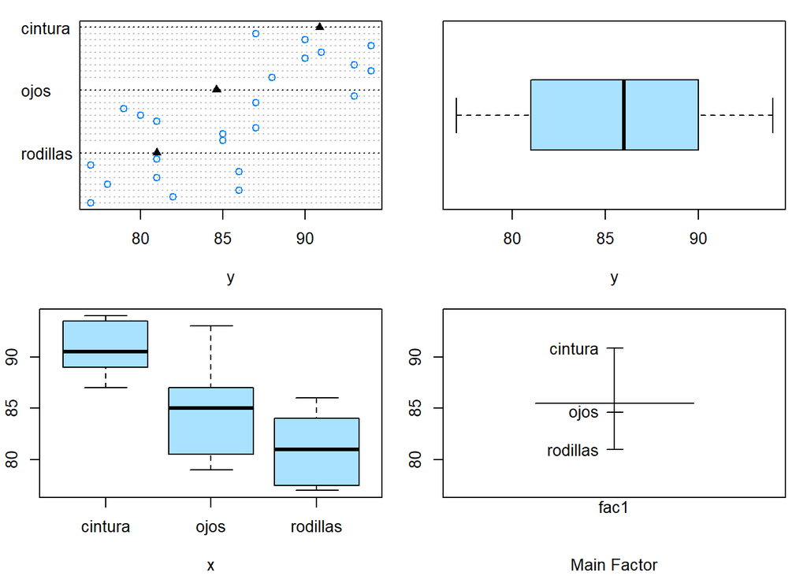

```r
oneway.plots(y, x)
```

```r
# Modelo ANOVA
modelo = aov(y ~ x)  # Función ANOVA
summary(modelo)
```

```
##             Df Sum Sq Mean Sq F value  Pr(>F)
## x            2  399.2  199.62   14.52 0.00011 ***
## Residuals   21  288.7   13.75
## ---
## Signif. codes:  0 '***' 0.001 '**' 0.01 '*' 0.05 '.' 0.1 ' ' 1
```

```r
# Comprobación de supuestos
# Primer paso: Obtener los residuos estandarizados
library(MASS)
r = stdres(modelo)  # Residuos estandarizados del ANOVA

# Normalidad
shapiro.test(r)
```

```
##
##  Shapiro-Wilk normality test
##
## data:  r
## W = 0.96156, p-value = 0.4706
```

```r
# Homocedasticidad (Levene)
library(lawstat)
levene.test(y, x)
```

```
##
##  Modified robust Brown-Forsythe Levene-type test based on the absolute
##  deviations from the median
##
## data:  y
## Test Statistic = 0.63559, p-value = 0.5395
```

```r
# Independencia
Box.test(r, lag=1, type="Ljung-Box")
```

```
##
##  Box-Ljung test
##
## data:  r
## X-squared = 0.0029592, df = 1, p-value = 0.9566
```

```r
# Comparaciones múltiples (si la HO del ANOVA se rechaza)
library(asbio)
pairw.anova(x = x, y = y, method = "bonf")  # Bonferroni
```

```
##
## 95% Bonferroni confidence intervals
##
##                       Diff    Lower    Upper  Decision Adj. p-value
## mucintura-muojos      6.25  1.42697 11.07303 Reject H0     0.008664
## mucintura-murodillas 9.875  5.05197 14.69803 Reject H0      8.4e-05
## muojos-murodillas    3.625 -1.19803  8.44803    FTR H0     0.192003
```

```r
pairw.anova(x = x, y = y, method = "tukey")  # Tukey
```

```
##
## 95% Tukey-Kramer confidence intervals
##
##                       Diff    Lower    Upper  Decision Adj. p-value
## mucintura-muojos      6.25  1.57674 10.92326 Reject H0     0.007789
## mucintura-murodillas 9.875  5.20174 14.54826 Reject H0        8e-05
## muojos-murodillas    3.625 -1.04826  8.29826    FTR H0     0.148325
```

```r
pairw.anova(x = x, y = y, method = "scheffe")  # Scheffe
```

```
##
## 95% Scheffe confidence intervals
##
##                       Diff    Lower    Upper  Decision Adj. P-value
## mucintura-muojos      6.25  1.36797 11.13203 Reject H0     0.010659
## mucintura-murodillas 9.875  4.99297 14.75703 Reject H0     0.000127
## muojos-murodillas    3.625 -1.25703  8.50703    FTR H0     0.172736
```

**13.7**

Se ha demostrado que el fertilizante a base de fosfato de amonio de magnesio, $MgNH_4PO_4$, es un proveedor eﬁcaz de los nutrientes necesarios para el crecimiento de las plantas. Los compuestos que suministra son muy solubles en agua, lo cual permite su aplicación directa sobre la superﬁcie del suelo o que se mezcle con el sustrato del crecimiento durante su colocación en una maceta. Se efectuó un estudio denominado *Eﬀect of Magnesium Ammonium Phosphate on Height of Chrysanthemus*, en la Universidad George Mason, para determinar el nivel óptimo posible de la fertilización, con base en la mejoría de la respuesta del crisantemo en cuanto a su crecimiento vertical. Se dividieron 40 semillas de crisantemo en 4 grupos de diez plantas cada uno. Se sembró cada una en una maceta similar que contenía un medio uniforme de crecimiento. Se agregó a cada grupo de plantas una concentración cada vez mayor de $MgNH_4PO_4$, medido en gramos por bushel. Se cultivaron durante cuatro semanas los cuatro grupos de plantas en condiciones uniformes en un invernadero. En la tabla que sigue se presentan los tratamientos y los cambios respectivos de sus alturas, medidas en centímetros:

Con un nivel de significacancia de 0.05, ¿podria concluirse que concentraciones diferentes de $MgNH_4PO_4$ afectan la estatura promedio que alcanzan los cristansenos? ¿que cantidad del fertilizandte parece ser la mejor?

```r
# Cargar los datos
g50 <- c(13.2, 12.4, 12.8, 17.2, 13.0, 14.0, 14.2, 21.6, 15.0, 20.0)  # 50 g/bu
g100 <- c(16.0, 12.6, 14.8, 13.0, 14.0, 23.6, 14.0, 17.0, 22.2, 24.4)  # 100 g/bu
g200 <- c(7.8, 14.4, 20.0, 15.8, 17.0, 27.0, 19.6, 18.0, 20.2, 23.2)  # 200 g/bu
g400 <- c(21.0, 14.8, 19.1, 15.8, 18.0, 26.0, 21.1, 22.0, 25.0, 18.2)  # 400 g/bu

# Crear un dataframe con los datos
y <- c(g50, g100, g200, g400)
x <- factor(rep(c("50 g/bu", "100 g/bu", "200 g/bu", "400 g/bu"), each = 10))

datos <- data.frame(y, x)

# ANOVA
modelo_anova <- aov(y ~ x, data = datos)

# Resumen del modelo ANOVA
summary(modelo_anova)
```

```
##             Df Sum Sq Mean Sq F value Pr(>F)
## x            3  119.8   39.93   2.252 0.0989 .
## Residuals   36  638.2   17.73
## ---
## Signif. codes:  0 '***' 0.001 '**' 0.01 '*' 0.05 '.' 0.1 ' ' 1
```

```r
# Comprobación de supuestos
# Obtener los residuos estandarizados
library(MASS)
r <- stdres(modelo_anova)

# Normalidad
shapiro.test(r)
```

```
##
##  Shapiro-Wilk normality test
##
## data:  r
## W = 0.95842, p-value = 0.1479
```

```r
# Homocedasticidad (Levene)
library(lawstat)
levene.test(y, x)
```

```
##
##  Modified robust Brown-Forsythe Levene-type test based on the absolute
##  deviations from the median
##
## data:  y
## Test Statistic = 0.50905, p-value = 0.6786
```

```r
# Independencia
Box.test(r, lag=1, type="Ljung-Box")
```

```
##
##  Box-Ljung test
##
## data:  r
## X-squared = 0.0050685, df = 1, p-value = 0.9432
```

```r
# Comparaciones múltiples (si la HO del ANOVA se rechaza)
library(asbio)
pairw.anova(x = x, y = y, method = "tukey")  # Usamos Tukey para comparaciones múltiples
```

```
##
## 95% Tukey-Kramer confidence intervals
##
##                        Diff    Lower   Upper Decision Adj. p-value
## mu100 g/bu-mu200 g/bu -1.14 -6.21144 3.93144   FTR H0     0.929696
## mu100 g/bu-mu400 g/bu -2.94 -8.01144 2.13144   FTR H0     0.412923
## mu200 g/bu-mu400 g/bu  -1.8 -6.87144 3.27144   FTR H0     0.774968
## mu100 g/bu-mu50 g/bu   1.82 -3.25144 6.89144   FTR H0     0.769115
## mu200 g/bu-mu50 g/bu   2.96 -2.11144 8.03144   FTR H0     0.406967
## mu400 g/bu-mu50 g/bu   4.76 -0.31144 9.83144   FTR H0     0.072412
```

**PRUEBAS BASADAS EN CHI CUADRADO**

*Resuelva solo los ejercicios impares*

**10.79**

Se lanza 180 veces un dado con los siguientes resultados:

| x | 1 | 2 | 3 | 4 | 5 | 6 |
| --- | --- | --- | --- | --- | --- | --- |
| f | 28 | 36 | 36 | 30 | 27 | 23 |

¿Es un dado balanceado? Utilice un nivel de signiﬁcancia de 0.01

```r
observado <- c(28, 36, 36, 30, 27, 23)

total_lanzamientos <- sum(observado)
esperado <- rep(total_lanzamientos / 6, 6)  # Se espera que cada número aparezca 180/6 veces

prueba_chi <- chisq.test(observado, p = rep(1/6, 6))

# Mostrar los resultados de la prueba
prueba_chi
```

```
##
##  Chi-squared test for given probabilities
##
## data:  observado
## X-squared = 4.4667, df = 5, p-value = 0.4844
```

**10.81**

Se supone que una máquina mezcla cacahuetes, avellanas, anacardos y pacanas a razón de 5:2:2:1.Se encuentra que una lata que contiene 500 de tales nueces mezcladas tiene 269 cacahuates, 112 avellanas, 74 anacardos y 45 pacanas. Al nivel de signiﬁcancia de 0.05, pruebe la hipótesis de que la máquina mezcla las nueces a una razón de 5:2:2:1.

```r
observado <- c(269, 112, 74, 45)  # Cacahuetes, avellanas, anacardos, pacanas

# Proporciones teóricas
proporciones <- c(5, 2, 2, 1)

# Calcular las frecuencias esperadas
total_nueces <- sum(observado)
esperado <- proporciones / sum(proporciones) * total_nueces

# Realizar la prueba de bondad de ajuste de chi-cuadrado
prueba_chi <- chisq.test(observado, p = proporciones/sum(proporciones))

# Mostrar los resultados de la prueba
prueba_chi
```

```
##
##  Chi-squared test for given probabilities
##
## data:  observado
## X-squared = 10.144, df = 3, p-value = 0.01738
```

**10.83**

Se extraen 3 cartas de una baraja ordinaria, con reemplazo, y se registra el número Y de espadas. Después de repetir el experimento 64 veces, se registran los siguientes resultados:

| x | 0 | 1 | 2 | 3 |  |  |
| --- | --- | --- | --- | --- | --- | --- |
| f | 21 | 31 | 12 | 0 |  |  |

Con un nivel de signiﬁcancia de 0.01, pruebe la hipótesis de que los datos registrados se pueden ajustar mediante la distribución binomial b(y; 3, 1/4), y = 0, 1, 2, 3.

```r
y <- c(0, 1, 2, 3)
observado <- c(21, 31, 12, 0)

# Parámetros de la distribución binomial
n <- 3
p <- 1/4

# Frecuencia esperada según la distribución binomial
esperado <- dbinom(y, size = n, prob = p) * sum(observado)

# Realizar la prueba de chi-cuadrado con simulación Monte Carlo
prueba_chi_mc <- chisq.test(x = observado, p = esperado / sum(esperado), simulate.p.value = TRUE, B = 10000)

# Mostrar los resultados de la prueba
prueba_chi_mc
```

```
##
##  Chi-squared test for given probabilities with simulated p-value (based
##  on 10000 replicates)
##
## data:  observado
## X-squared = 3.9259, df = NA, p-value = 0.2524
```

**10.85**

Se lanza una moneda hasta que sale una cara y se registra el número de lanzamientos X. Después de repetir el experimento 256 veces, obtenemos los siguientes resultados:

| x | 1 | 2 | 3 | 4 | 5 | 6 | 7 | 8 |
| --- | --- | --- | --- | --- | --- | --- | --- | --- |
| f | 136 | 60 | 34 | 12 | 9 | 1 | 3 | 1 |

Con un nivel de signiﬁcancia de 0.05 pruebe la hipótesis de que la distribución observada de X se puede ajustar por la distribución geométrica g(x; 1/2), x = 1, 2, 3, . .

```r
x <- 1:8
observado <- c(136, 60, 34, 12, 9, 1, 3, 1)

# Parámetro de la distribución geométrica
p <- 1/2

# Calcular las frecuencias esperadas bajo la hipótesis de una distribución geométrica
esperado <- dgeom(x - 1, prob = p) * sum(observado)

# Realizar la prueba de bondad de ajuste de chi-cuadrado
prueba_chi <- chisq.test(x = observado, p = esperado / sum(esperado))
# Mostrar los resultados de la prueba
prueba_chi
```

```
##
##  Chi-squared test for given probabilities
##
## data:  observado
## X-squared = 4.7275, df = 7, p-value = 0.6932
```

**10.87**

```r
#Resolver la pregunta 10.86

observado_83 <- c(18, 28, 14, 4)

# Parámetros de la distribución binomial
n <- 3
p <- 1/4

# Calcular las frecuencias esperadas según la distribución binomial
esperado_83 <- dbinom(0:3, size = n, prob = p) * sum(observado_83)

# Realizar la prueba de bondad de ajuste de chi-cuadrado
prueba_chi_83 <- chisq.test(x = observado_83, p = esperado_83 / sum(esperado_83))
# Mostrar los resultados de la prueba
prueba_chi_83
```

```
##
##  Chi-squared test for given probabilities
##
## data:  observado_83
## X-squared = 14.815, df = 3, p-value = 0.001982
```

```r
##Ahora se responde la pregunta 10.87

# Valores observados (nuevo conjunto de datos)
observado_85 <- c(140, 58, 32, 10, 9, 2, 4, 1)

# Parámetro de la distribución geométrica
p <- 1/2

# Calcular las frecuencias esperadas bajo la hipótesis de una distribución geométrica
esperado_85 <- dgeom(0:7, prob = p) * sum(observado_85)

# Realizar la prueba de bondad de ajuste de chi-cuadrado
prueba_chi_85 <- chisq.test(x = observado_85, p = esperado_85 / sum(esperado_85))
# Mostrar los resultados de la prueba
prueba_chi_85
```

```
##
##  Chi-squared test for given probabilities
##
## data:  observado_85
## X-squared = 7.031, df = 7, p-value = 0.4257
```

**10.91**

Una muestra aleatoria de 90 adultos se clasiﬁca de acuerdo con su género y el número de horas que pasan viendo la televisión durante una semana:

[output not shown]

Utilice un nivel de signiﬁcancia de 0.01 y pruebe la hipótesis de que el tiempo que pasan viendo televisión es independiente de si el espectador es hombre o mujer.

```r
# Crear la tabla de contingencia
tabla <- matrix(c(15, 27, 29, 19), nrow = 2, byrow = TRUE)
colnames(tabla) <- c("Masculino", "Femenino")
rownames(tabla) <- c("Más de 25 horas", "Menos de 25 horas")
tabla
```

```
##                   Masculino Femenino
## Más de 25 horas          15       27
## Menos de 25 horas        29       19
```

```r
# Realizar la prueba de independencia de chi-cuadrado
prueba_chi <- chisq.test(tabla)

# Mostrar los resultados de la prueba
prueba_chi
```

```
##
##  Pearson's Chi-squared test with Yates' continuity correction
##
## data:  tabla
## X-squared = 4.5262, df = 1, p-value = 0.03338
```

**10.93**

```r
Oi = matrix(c(162,310,258,280,
            118,196,193,175,
            451,996,458,390,
            18,25,10,19), ncol = 4)

colnames(Oi) = c("Asalto", "Robo", "Hurto", "Homicidio")
rownames(Oi) = c("D1","D2","D3","D4")
Oi
```

```
##    Asalto Robo Hurto Homicidio
## D1    162  118   451        18
## D2    310  196   996        25
## D3    258  193   458        10
## D4    280  175   390        19
```

```r
#Usando la funcion chisq.test de r

chisq.test(Oi)
```

```
##
##  Pearson's Chi-squared test
##
## data:  Oi
## X-squared = 124.53, df = 9, p-value < 2.2e-16
```

```r
#Al ser menor el pvalor a 0.01 enonces el crimen si depende del lugar de la ciudad



prueba = chisq.test(Oi)
prueba
```

```
##
##  Pearson's Chi-squared test
##
## data:  Oi
## X-squared = 124.53, df = 9, p-value < 2.2e-16
```

```r
prueba$expected
```

```
##      Asalto     Robo    Hurto Homicidio
## D1 186.3735 125.8482 423.4922  13.28603
## D2 379.9630 256.5691 863.3814  27.08647
## D3 228.6746 154.4119 519.6120  16.30155
## D4 214.9889 145.1707 488.5144  15.32594
```

```r
prueba$residuals
```

```
##       Asalto       Robo     Hurto  Homicidio
## D1 -1.785359 -0.6995981  1.336696  1.2932697
## D2 -3.589203 -3.7813683  4.513393 -0.4009007
## D3  1.939259  3.1053654 -2.702872 -1.5607490
## D4  4.433834  2.4757288 -4.457189  0.9384959
```

```r
prueba$statistic
```

```
## X-squared
##  124.5297
```

```r
prueba$p.value
```

```
## [1] 1.576243e-22
```

```r
addmargins(Oi)
```

```
##     Asalto Robo Hurto Homicidio  Sum
## D1     162  118   451        18  749
## D2     310  196   996        25 1527
## D3     258  193   458        10  919
## D4     280  175   390        19  864
## Sum   1010  682  2295        72 4059
```

**10.95**

```r
# Crear la tabla de contingencia
tabla <- matrix(c(65, 66, 40, 34, 42, 30, 33, 42, 93, 54, 27, 24), nrow = 3, byrow = TRUE)
colnames(tabla) <- c("Craig", "Giles", "Franklin", "Montgomery")
rownames(tabla) <- c("A favor", "En contra", "Sin opinión")
tabla
```

```
##             Craig Giles Franklin Montgomery
## A favor        65    66       40         34
## En contra      42    30       33         42
## Sin opinión    93    54       27         24
```

```r
# Realizar la prueba de homogeneidad de chi-cuadrado
prueba_chi <- chisq.test(tabla)

# Mostrar los resultados de la prueba
prueba_chi
```

```
##
##  Pearson's Chi-squared test
##
## data:  tabla
## X-squared = 31.099, df = 6, p-value = 2.427e-05
```

**10.97**

Las siguientes respuestas con respecto al estándar de vida al momento de una encuesta de opinión independiente de 1000 familias contra un año antes parece estar de acuerdo con los resultados de un estudio publicado en Across the Board (junio de 1981):

**Estandar de vida**

| Periodo | Algo Mejor | Igual | No tan bueno | Total |
| --- | --- | --- | --- | --- |
| 1980: Enero | 72 | 144 | 84 | 300 |
| Mayo | 63 | 135 | 102 | 300 |
| Septiembre | 47 | 100 | 53 | 200 |
| 1981: Enero | 40 | 105 | 55 | 200 |

Pruebe la hipótesis de que las proporciones de familias dentro de cada estándar de vida son las mismas para cada uno de los cuatro periodos. Utilice un valor P.

```r
Oi <- matrix(c(72, 63, 47, 40,   # Algo mejor
               144, 135, 100, 105, # Igual
               84, 102, 53, 55),   # No tan bueno
             ncol = 3, byrow = FALSE)

colnames(Oi) <- c("Algo mejor", "Igual", "No tan bueno")
rownames(Oi) <- c("1980 Enero", "1980 Mayo", "1980 Septiembre", "1981 Enero")
Oi
```

```
##                 Algo mejor Igual No tan bueno
## 1980 Enero              72   144           84
## 1980 Mayo               63   135          102
## 1980 Septiembre         47   100           53
## 1981 Enero              40   105           55
```

```r
# Realizar la prueba de Chi-cuadrado
prueba <- chisq.test(Oi)
prueba
```

```
##
##  Pearson's Chi-squared test
##
## data:  Oi
## X-squared = 5.9245, df = 6, p-value = 0.4317
```

```r
# Mostrar las frecuencias esperadas
prueba$expected
```

```
##                 Algo mejor Igual No tan bueno
## 1980 Enero            66.6 145.2         88.2
## 1980 Mayo             66.6 145.2         88.2
## 1980 Septiembre       44.4  96.8         58.8
## 1981 Enero            44.4  96.8         58.8
```

```r
# Mostrar los residuos
prueba$residuals
```

```
##                 Algo mejor       Igual No tan bueno
## 1980 Enero       0.6616932 -0.09958592   -0.4472136
## 1980 Mayo       -0.4411288 -0.84648032    1.4694161
## 1980 Septiembre  0.3901951  0.32524625   -0.7563788
## 1981 Enero      -0.6603302  0.83344352   -0.4955585
```

```r
# Mostrar el valor del estadístico Chi-cuadrado
prueba$statistic
```

```
## X-squared
##  5.924451
```

```r
# Mostrar el p-valor
prueba$p.value
```

```
## [1] 0.4317062
```